# M2 Visualisation d’informations sur R

ggplot2 - partie 2: Mise en forme avancée

Arnaud MILET  
arnaud.milet@d-sidd.com

# ggplot() vs qplot()

Nous avons vu comment créer des graphiques avec qplot. Si vous devez personnaliser vos sorties graphiques, il est alors préférable de basculer vers la fonction ggplot() qui s’avère beaucoup plus complète. C’est une fonction *générique* qui vous permettra de réaliser n’importe quel graphique. Elle est articulée autour de “Grammar of graphics” et reprend certains termes de qplot. En particulier les géométries.

# Grammar of Graphics

Construire tous les graphiques à partir d’un même petit nombre d’éléments :

- data : Données qui contient les variables que l’on veut représenter ;
- aesthetics(aes) : Variables à représenter, couleurs, tailles, formes ;
- geometrics(geom…) : Type de représentation;
- statistics(stat…) : Transformations des données éventuelles ;
- scales(scale…) : Lien entre les données et les aesthetics.
- coordinate
- position
- faceting

# Réaliser un graphique, les différentes écritures

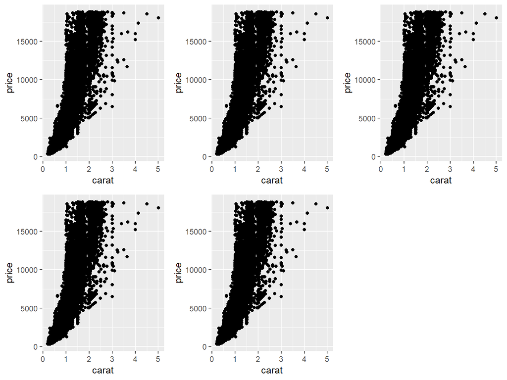

```r
#Ecriture 1
g1<-ggplot(data = diamonds,aes(x=carat,y=price))+
  geom_point()

#Ecriture 2
g2<-ggplot()+geom_point(data = diamonds,aes(x=carat,y=price))

#Ecriture 3
g3<-ggplot()
g3<-g3+geom_point(data = diamonds,aes(x=carat,y=price))

#Ecriture 4
g4<-ggplot(data = diamonds,aes(x=carat,y=price))
g4<-g4+geom_point()

#Ecriture 5
g5<-ggplot(data = diamonds)
g5<-g5+geom_point(aes(x=carat,y=price))

grid.arrange(g1,g2,g3,g4,g5,ncol=3,nrow=2)
```

# geom_ & aesthetics

### aesthetic

Dans ggplot, aesthetic signifie ce que l’on peut voir * position (i.e., sur les axes x et y) * color (couleur de contour) * fill (couleur intérieure) * shape (la forme des points) * linetype (la forme des lignes) * size

Chaque type de geomtrie accepte uniquement certains arguments. L’aide apporte ces réponses La fonction aes() définit ce que l’on va reporter sur notre graphique.

### Géometrie

La géométrie représente la forme de représentation que l’on souhaite avoir. Voici quelques exemples issus de l’aide: help.search(“geom_”, package = “ggplot2”)

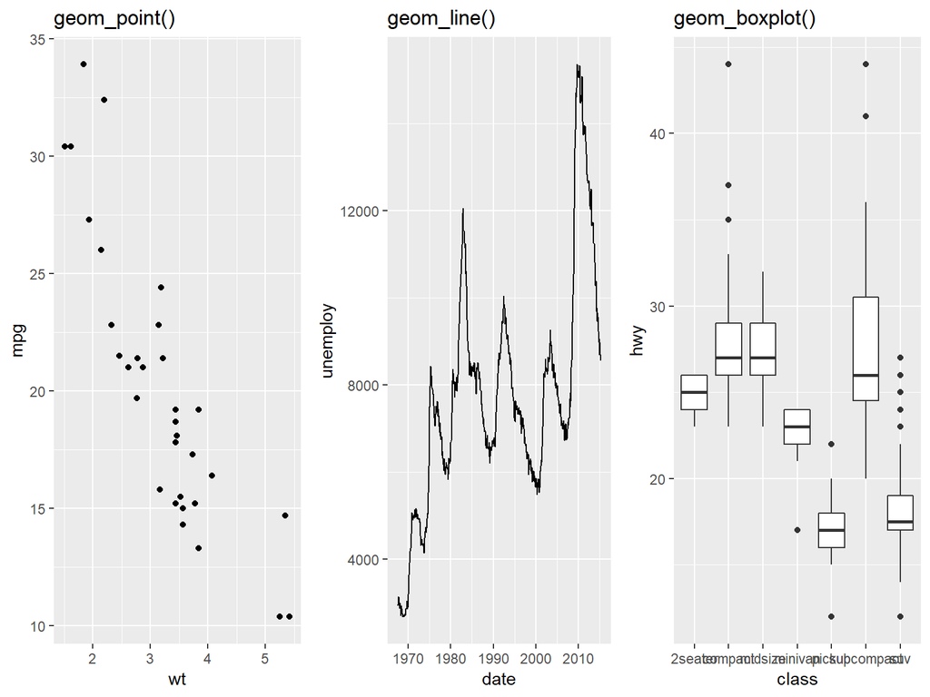

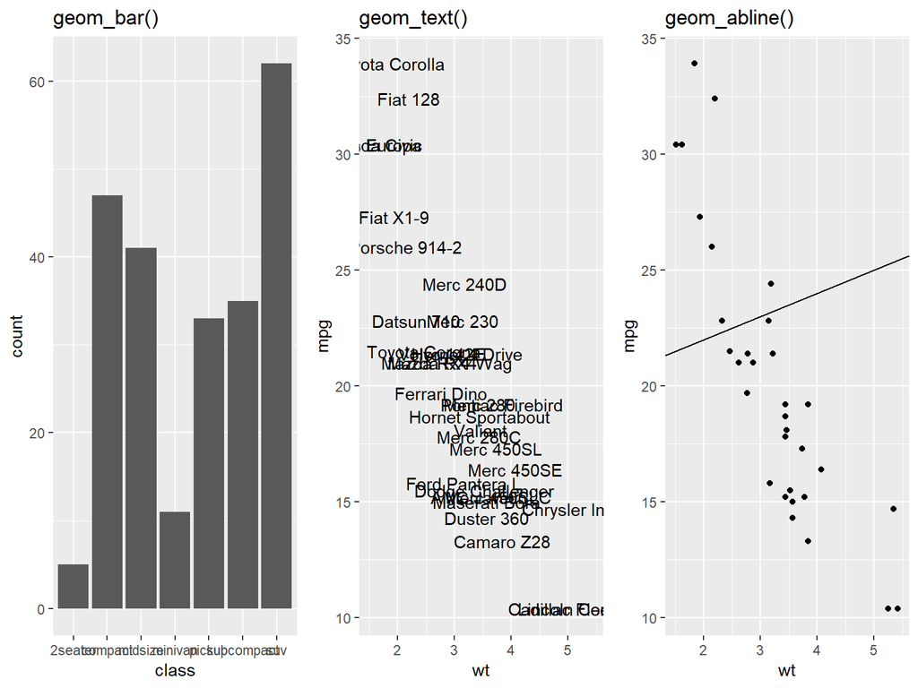

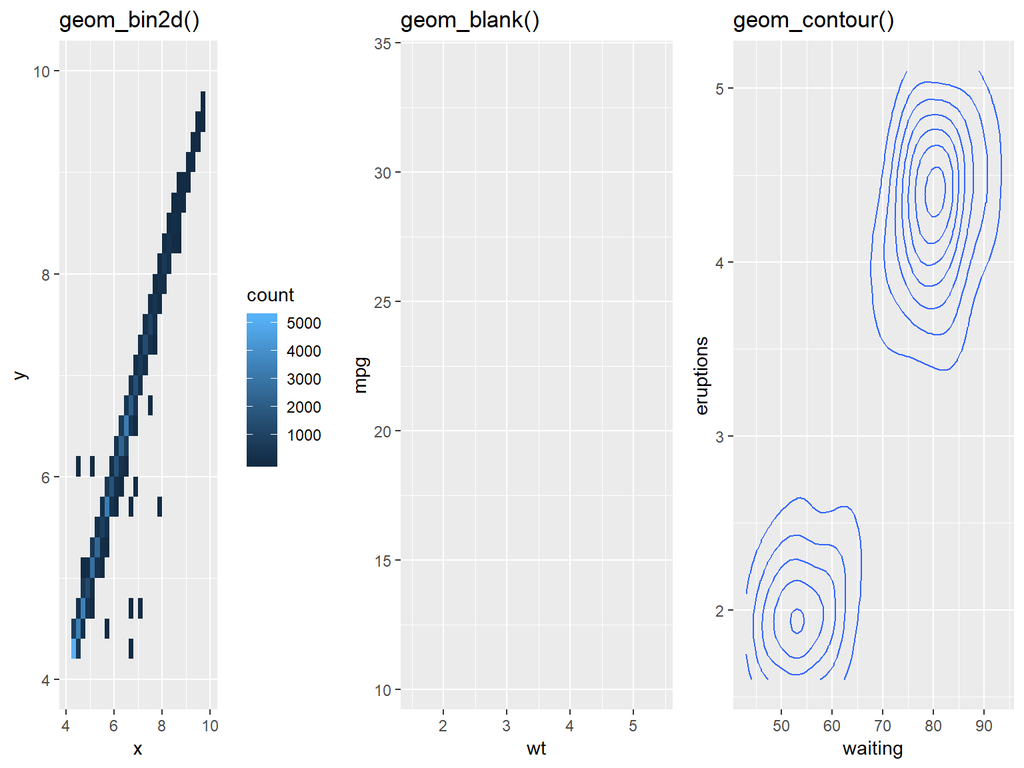

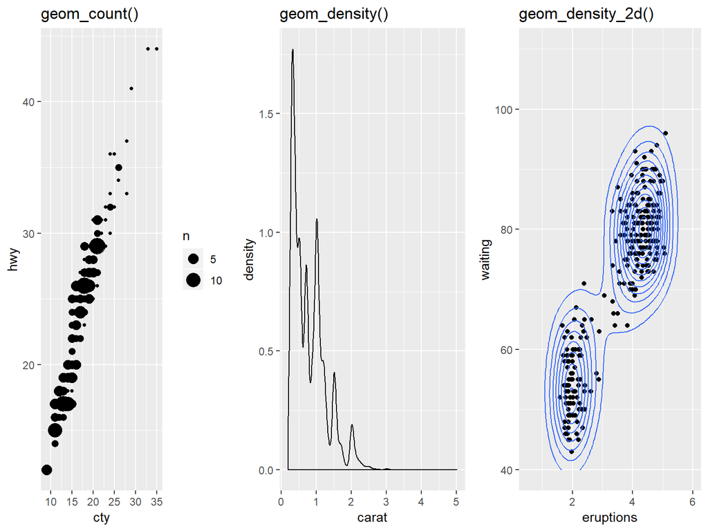

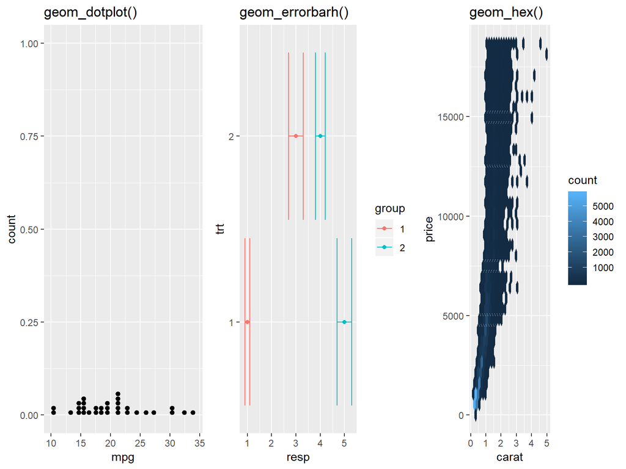

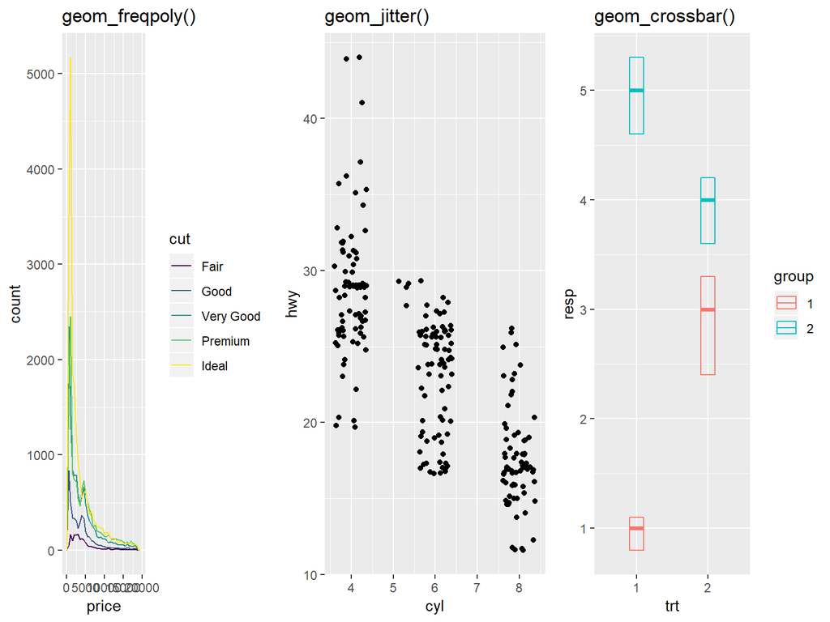

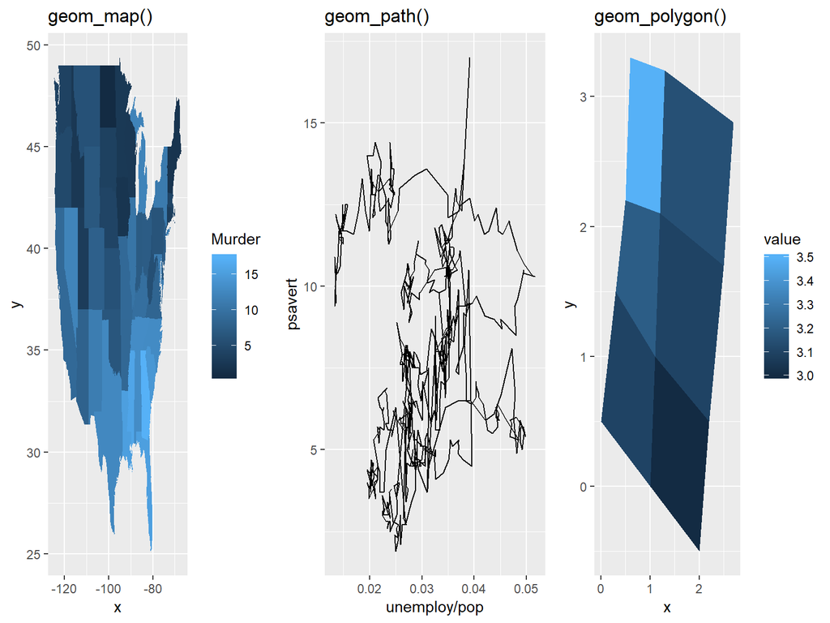

```
## Smoothing formula not specified. Using: y ~ x
```

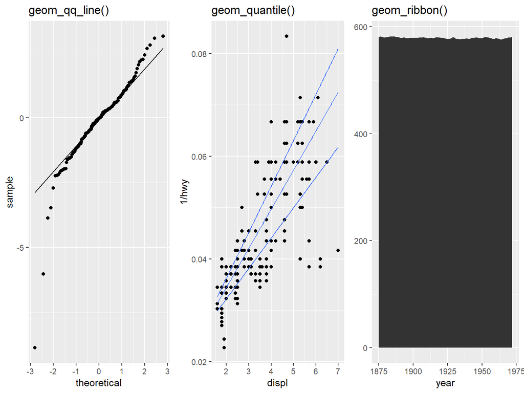

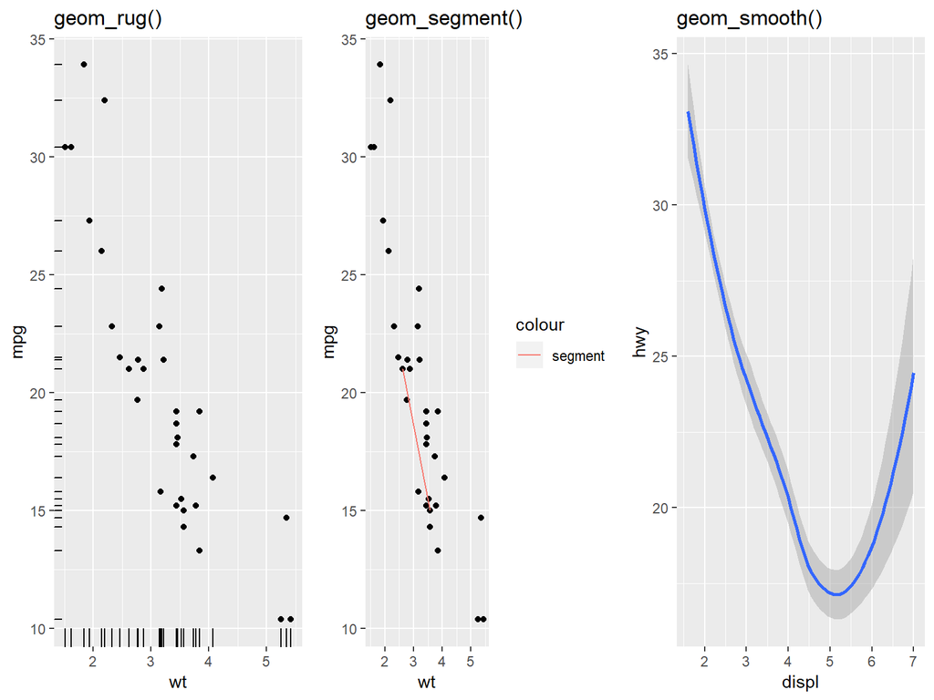

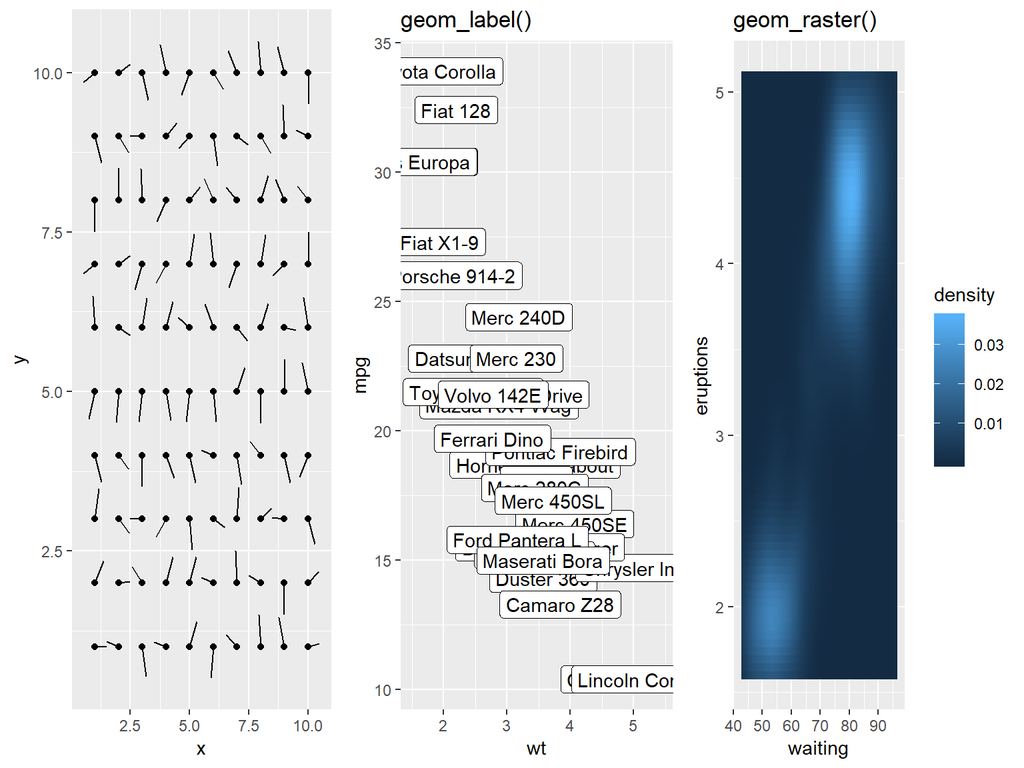

# Au delà de 2 dimensions:

Au delà de 2 dimensions, on peut représenter les données avec:

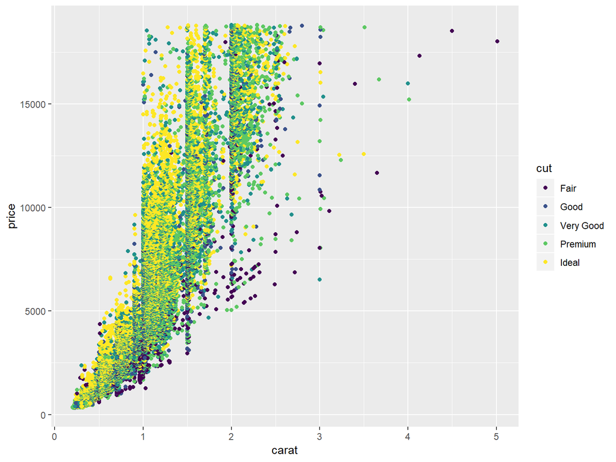

```r
#Couleurs: color
ggplot(diamonds, aes(x=carat, y=price, color=cut))+
  geom_point()
```

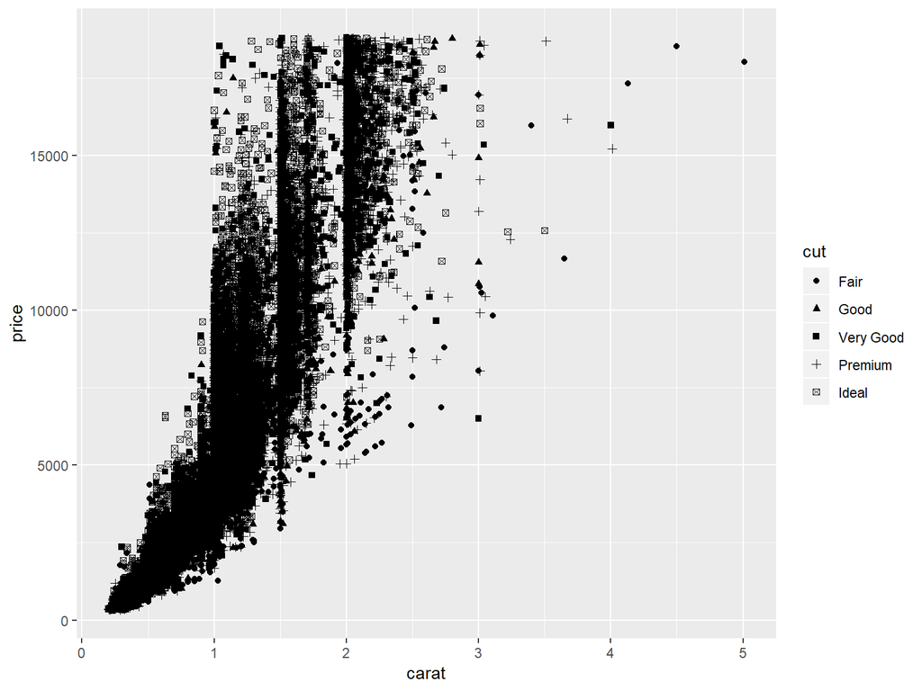

```r
#Forme: shape
ggplot(diamonds, aes(x=carat, y=price, shape=cut))+
  geom_point()
```

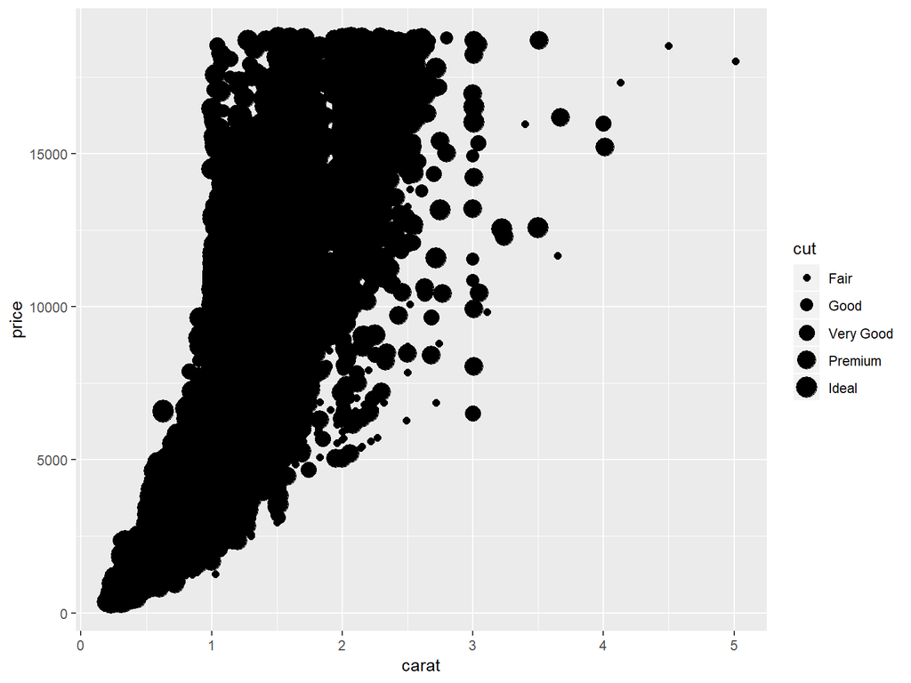

```r
#Taille: size
ggplot(diamonds, aes(x=carat, y=price, size=cut))+
  geom_point()
```

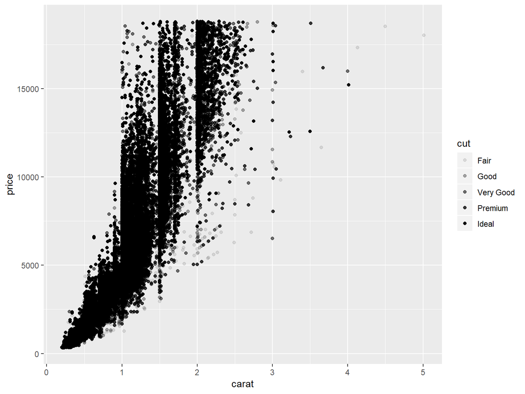

```r
#Transparence/Opacité: alpha
ggplot(diamonds, aes(x=carat, y=price, alpha=cut))+
  geom_point()
```

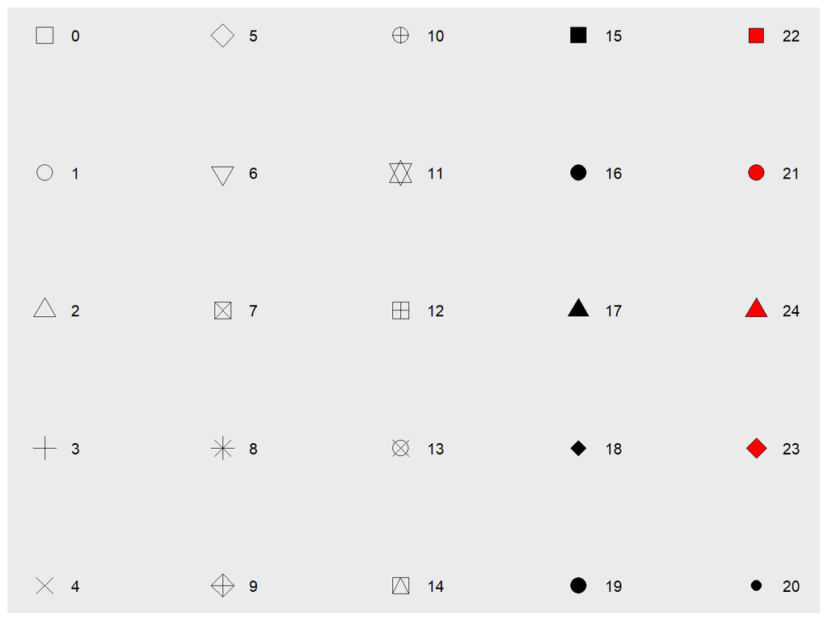

```r
#Les formes possibles
shapes <- data.frame(
  shape = c(0:19, 22, 21, 24, 23, 20),
  x = 0:24 %/% 5,
  y = -(0:24 %% 5)
)

ggplot(shapes, aes(x, y)) +
  geom_point(aes(shape = shape), size = 5, fill = "red") +
  geom_text(aes(label = shape), hjust = 0, nudge_x = 0.15) +
  scale_shape_identity() +
  expand_limits(x = 4.1) +
  scale_x_continuous(NULL, breaks = NULL) +
  scale_y_continuous(NULL, breaks = NULL)
```

```r
#Les couleurs
colors() #Couleurs prédéfinies
```

```
##   [1] "white"                "aliceblue"            "antiquewhite"
##   [4] "antiquewhite1"        "antiquewhite2"        "antiquewhite3"
##   [7] "antiquewhite4"        "aquamarine"           "aquamarine1"
##  [10] "aquamarine2"          "aquamarine3"          "aquamarine4"
##  [13] "azure"                "azure1"               "azure2"
##  [16] "azure3"               "azure4"               "beige"
##  [19] "bisque"               "bisque1"              "bisque2"
##  [22] "bisque3"              "bisque4"              "black"
##  [25] "blanchedalmond"       "blue"                 "blue1"
##  [28] "blue2"                "blue3"                "blue4"
##  [31] "blueviolet"           "brown"                "brown1"
##  [34] "brown2"               "brown3"               "brown4"
##  [37] "burlywood"            "burlywood1"           "burlywood2"
##  [40] "burlywood3"           "burlywood4"           "cadetblue"
##  [43] "cadetblue1"           "cadetblue2"           "cadetblue3"
```

[output cut: 204 more lines]

```r
rgb(1,1,1) #renvoie le code hexadecimal correspondant
```

```
## [1] "#FFFFFF"
```

```r
rgb(255,255,255,maxColorValue=255)
```

```
## [1] "#FFFFFF"
```

```r
colorRampPalette(c("blue", "red"))(4)
```

```
## [1] "#0000FF" "#5500AA" "#AA0055" "#FF0000"
```

```r
library(dplyr) # nécessaire pour la manipulation de données
```

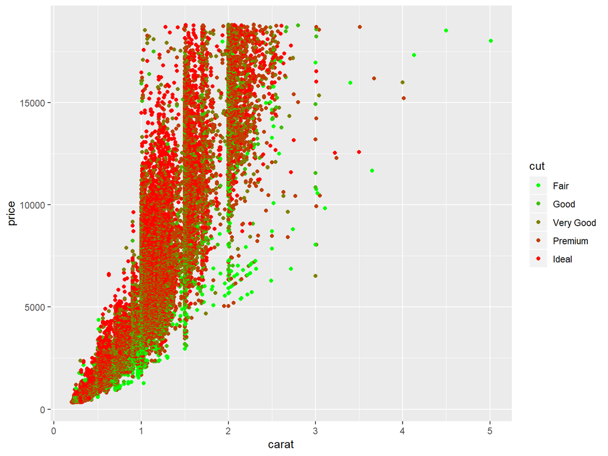

```r
library(magrittr) #nécessaire pour l'écriture en pipe

Pallette_Couleur<-colorRampPalette(c("green", "red"))

couleurs_graphe<-diamonds%>%
  distinct(cut)%>%
  nrow()%>%
  Pallette_Couleur()

ggplot(diamonds, aes(x=carat, y=price, color=cut))+
  geom_point()+
  scale_color_manual(values=couleurs_graphe)
```

# Superposer des géometries: les couches

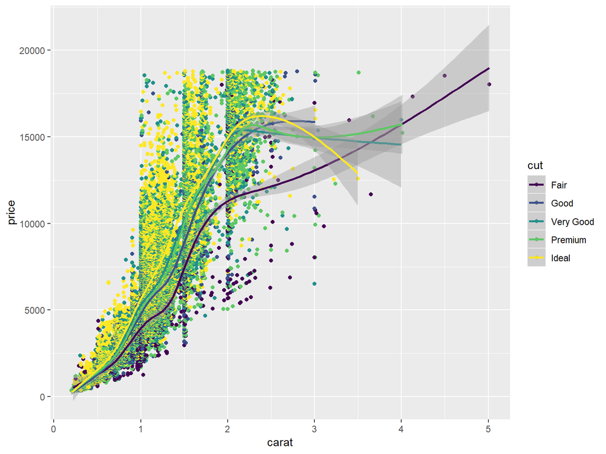

```r
ggplot(diamonds, aes(x=carat, y=price, color=cut)) +
  geom_point() +
  geom_smooth()
```

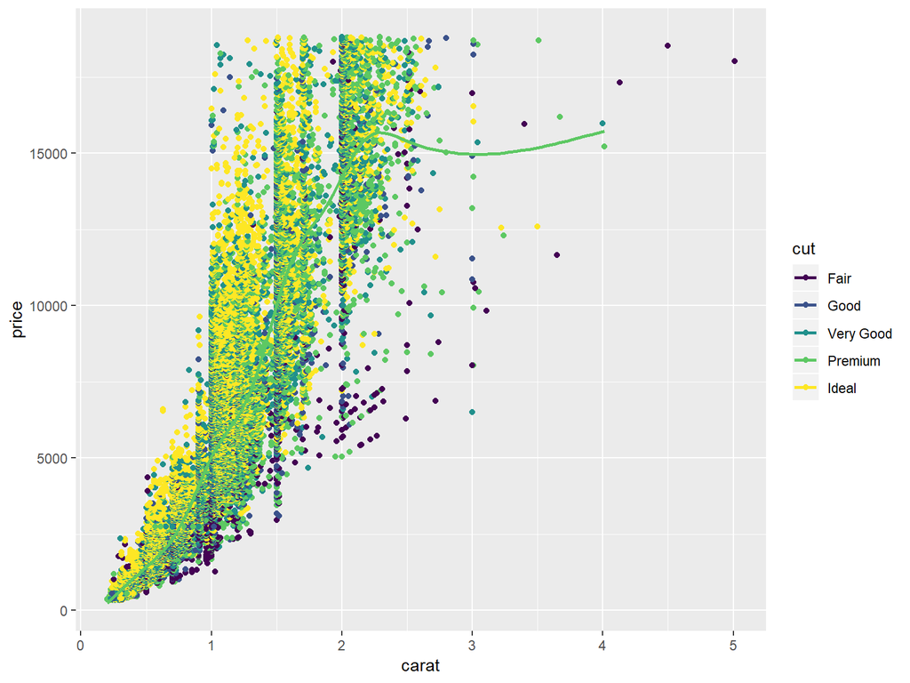

```r
ggplot(diamonds, aes(x=carat, y=price, color=cut)) +
  geom_point() +
  geom_smooth(data = filter(diamonds, cut == "Premium"), se = FALSE)
```

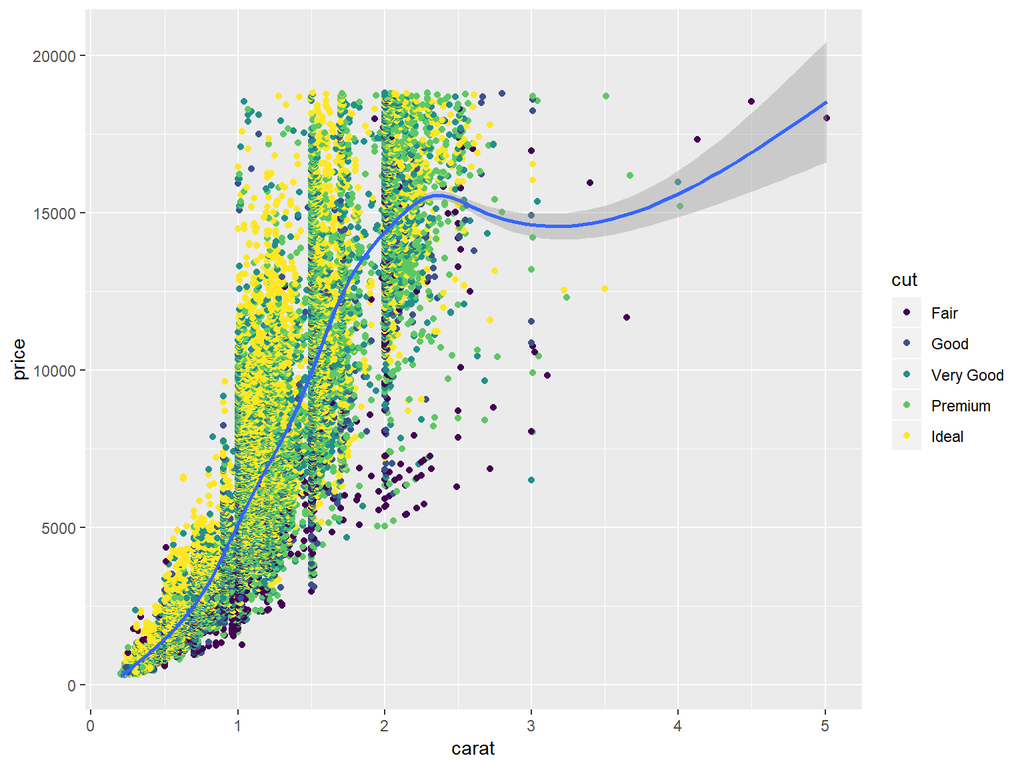

```r
ggplot(diamonds, aes(x=carat, y=price)) +
  geom_point(aes(color=cut)) +
  geom_smooth()
```

# Transformation statistiques

Certains graphiques (comme les nuages de points) ne requièrent pas de transformations. D’autres comme les boxplots ou les histogrammes le nécessitent.

Chaque type de géométrie a une transformation statistique par défaut. Pour geom_histogram(), la statistique par défaut est stat_bin.

```r
args(geom_histogram)
```

```
## function (mapping = NULL, data = NULL, stat = "bin", position = "stack",
##     ..., binwidth = NULL, bins = NULL, na.rm = FALSE, show.legend = NA,
##     inherit.aes = TRUE)
## NULL
```

```r
args(geom_point)
```

```
## function (mapping = NULL, data = NULL, stat = "identity", position = "identity",
##     ..., na.rm = FALSE, show.legend = NA, inherit.aes = TRUE)
## NULL
```

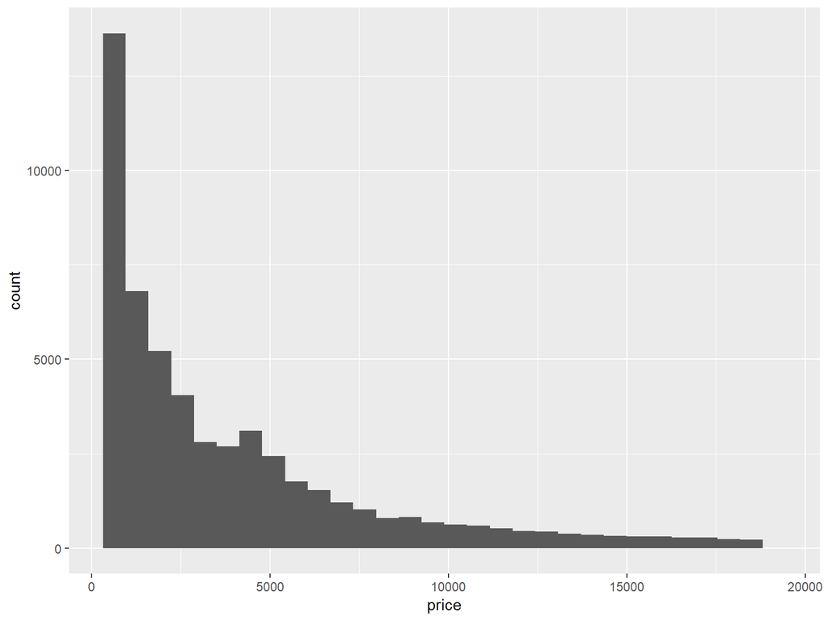

```r
p2 <- ggplot(diamonds, aes(x = price))
p2 + geom_histogram()
```

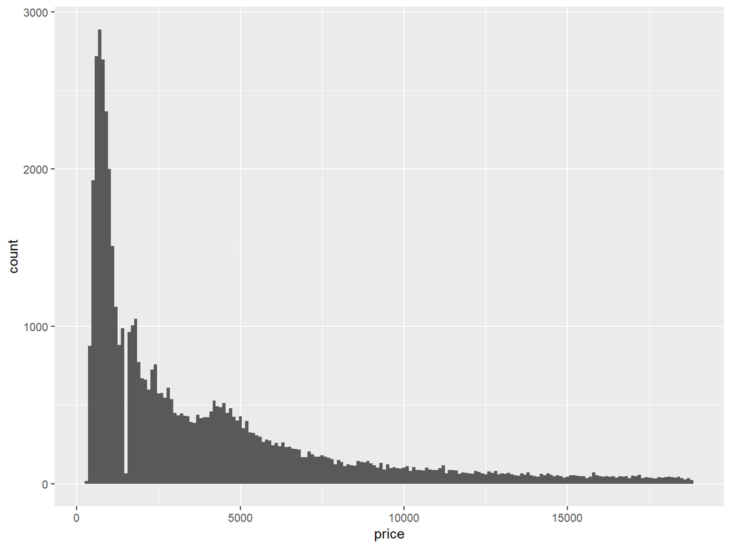

```r
#On peut changer la largeur des intervalles
p2 + geom_histogram(stat = "bin", binwidth=100)
```

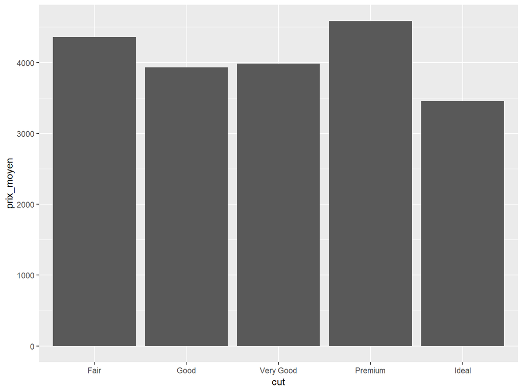

```r
Somme_Diamants <- diamonds%>%
  group_by(cut)%>%
  summarise(prix_moyen=mean(price))

# Une erreur
# ggplot(Somme_Diamants, aes(x=cut, y=prix_moyen)) +
# geom_bar()

ggplot(Somme_Diamants, aes(x=cut, y=prix_moyen)) +
  geom_bar(stat='identity')
```

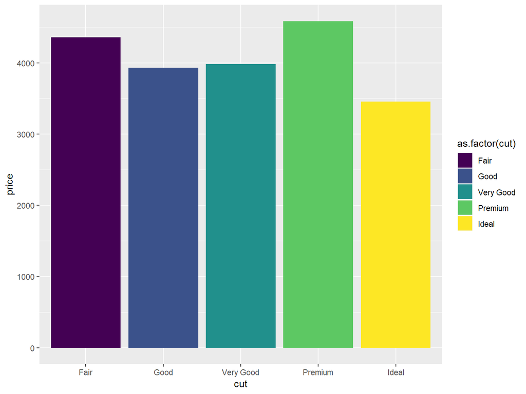

```r
ggplot(diamonds, aes(x=cut, y=price, fill=as.factor(cut))) +
  geom_bar(stat = "summary", fun.y = "mean")
```

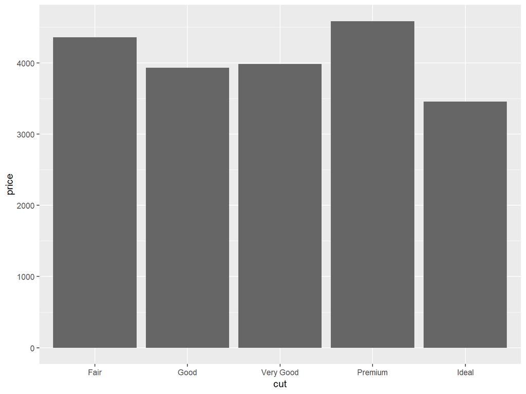

```r
ggplot(diamonds, aes(x=cut, y=price, fill=as.factor(cut))) +
  geom_bar(stat = "summary", fun.y = "mean",fill="#666666")
```

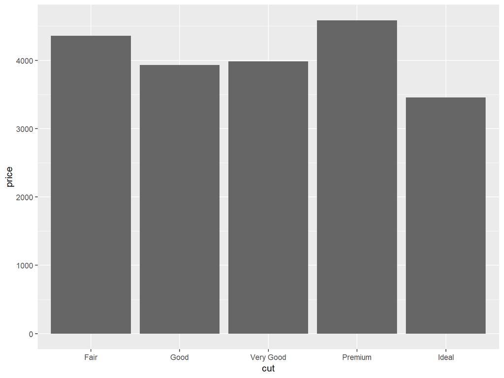

```r
ggplot(diamonds, aes(x=cut, y=price, fill=as.factor(cut))) +
  geom_bar(stat = "summary", fun.y = "mean")+
  scale_fill_manual(values=rep("#666666",5))+
  theme(
    legend.position = "none"
  )
```

# Scale: mise en forme des aesthetics

Nous avons vu ci-dessus que les variables pouvaient être représentées par:  
• color • fill  
• size  
• shape • linetype

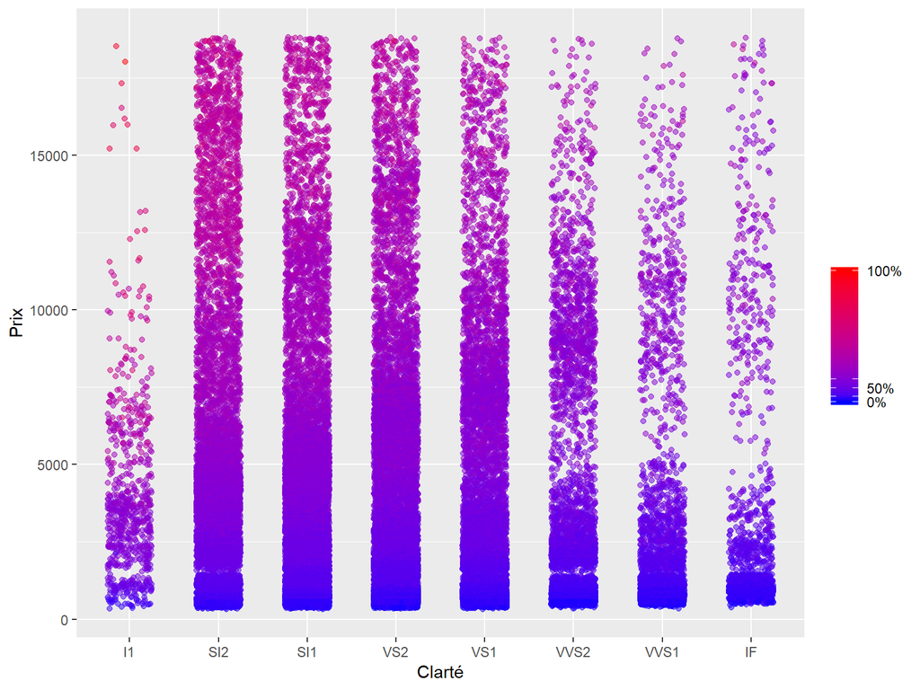

```r
p2<-ggplot(diamonds, aes(x=clarity,y=price,color=carat))+
  geom_point()

p3<-ggplot(diamonds, aes(x=clarity,y=price,color=carat))+
  geom_point(alpha = 0.5,
             size = 1.5,
             position = position_jitter(width = 0.25, height = 0))

p3+scale_x_discrete(name='Clarté')+
  scale_y_continuous(name='Prix')+
  scale_color_continuous(name="",
                         breaks = quantile(diamonds$carat),
                         labels = c("0%", "","50%","","100%"),
                         low = "blue", high = "red")
```

# Les labels

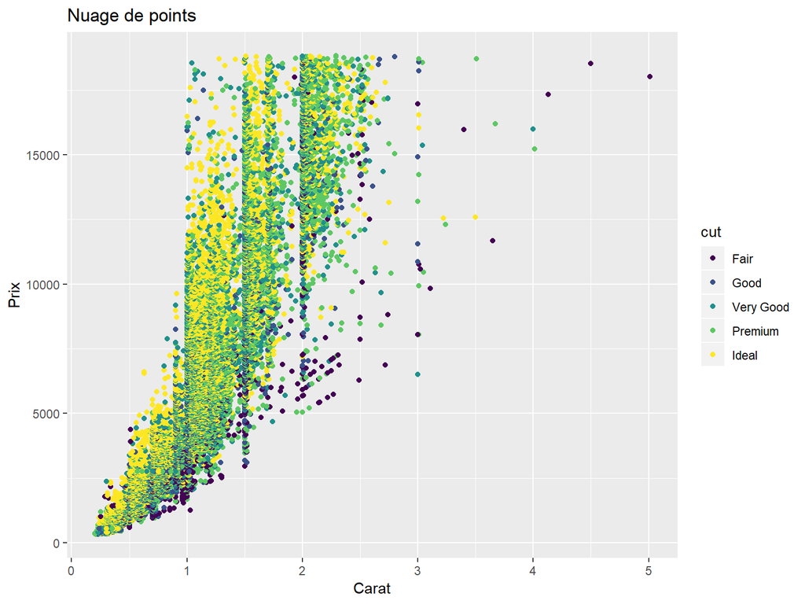

```r
gg <- ggplot(diamonds, aes(x=carat, y=price, color=cut))+
  geom_point() +
  labs(title="Nuage de points", x="Carat", y="Prix")
gg
```

# Les thèmes

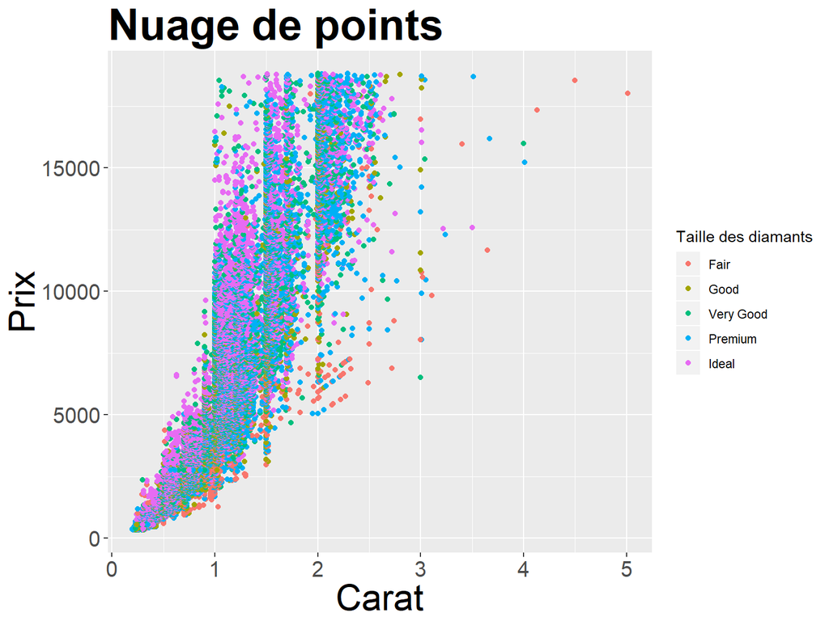

```r
gg1 <- gg +
  theme(plot.title=element_text(size=30, face="bold"),
                  axis.text.x=element_text(size=15),
                  axis.text.y=element_text(size=15),
                  axis.title.x=element_text(size=25),
                  axis.title.y=element_text(size=25)) +
  scale_color_discrete(name="Taille des diamants")

gg1
```

# Les facets

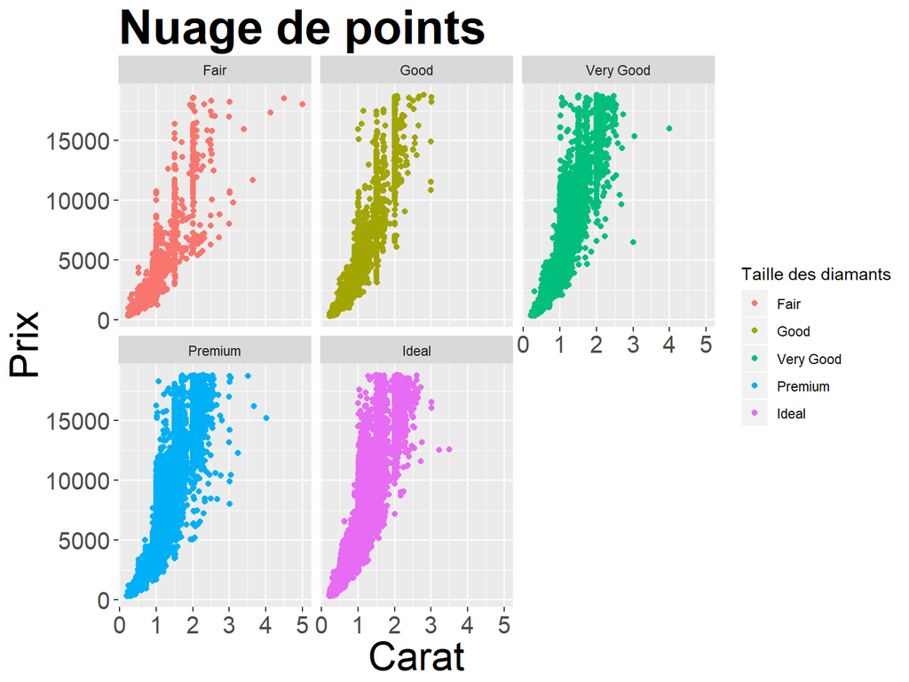

```r
gg1 +
  facet_wrap( ~ cut, ncol=3)
```

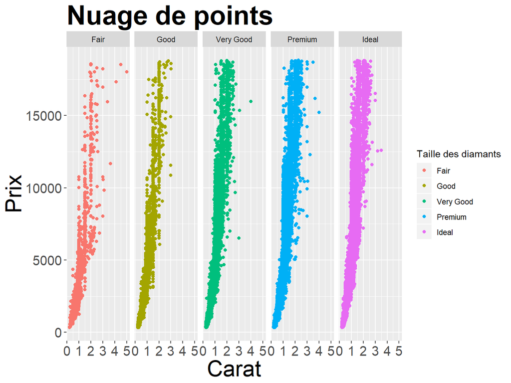

```r
gg1 +
  facet_grid( ~ cut)
```

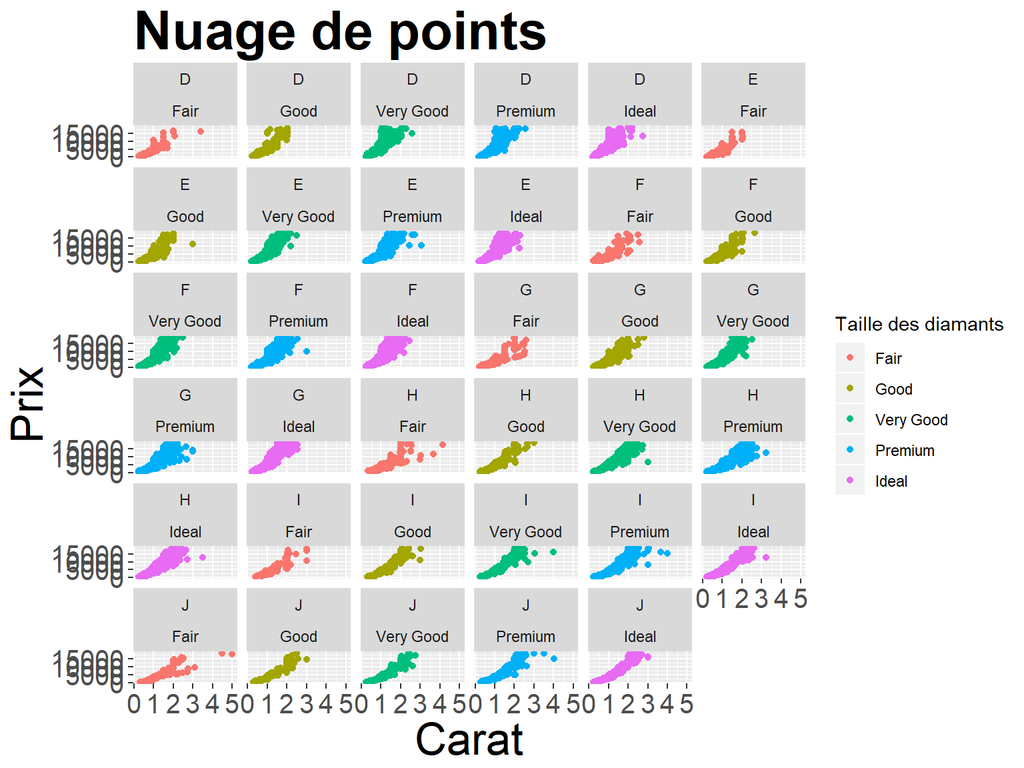

```r
gg1 + facet_wrap(color ~ cut)
```